# Analysis of the Worth of Attending College in 2019

## S.R. Mazeski

### Senior Computational Data Science student at The Pennsylvania State University

stephenmazeski@gmail.com  
stephenmazeski.com

The purpose for this project is to take various datasets in order to analyze if pursuing a college degree has the same worth as it has throughout history. The problem comes from multiple reasons that I had identified before analysis. The first reason is the increased percentage of high schoolers attending college each year. BLS.gov has statistics that depict a 20% positive change in all students enrolled in a four year degree program over the last 60 years. With labor jobs become more and more sparse, it makes sense that more students would like to pursue further education, but at what cost?

The second reason is the cost analysis specifically today. How much money are we making today versus 60 years ago when it would cost $500 per semester.

```r
library(mosaic)
library(tidyverse)
library(DataComputing)
library(lubridate)
library(maps)
#A 52
#B 191
#F 50
#G 123
#H 105
#A 39, 60, 77
#B 39/60
```

```r
# Data has been hard imported into Avg_CPI
# CPI is the Consumer Price Index for the USA. Below is the head of the data along with an explination of its importance in this analysis.
head(Avg_CPI)
```

```
  YEAR    AVE.
1 2019 255.151
2 2018 251.107
3 2017 245.120
4 2016 240.008
5 2015 237.017
6 2014 236.736
```

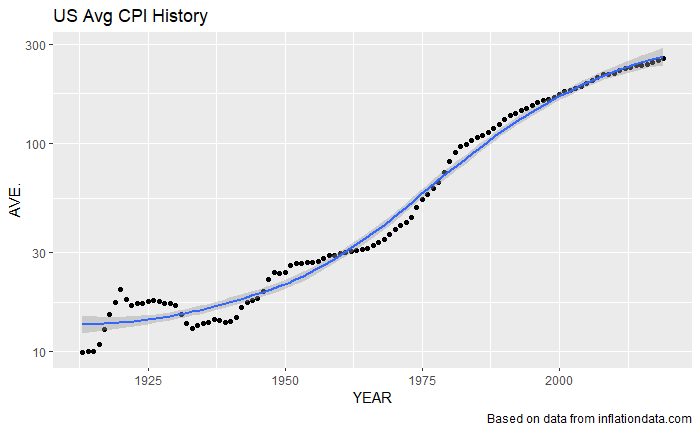

```r
# Log Graph of CPI highlights change in Average CPI.
ggplot(data=Avg_CPI,aes(x=YEAR,y=AVE.))+geom_point()+scale_y_log10() + geom_smooth() + labs(title = "US Avg CPI History", caption = "Based on data from inflationdata.com")
```

We can use this as a tool to guage the worth of USD over the course of the last century.

I think that the graph looks messy however with the arbituary AVE. and numbers from ~9 to 300.

I will use data wrangling in order to change this dataframe, and recreate the graphic.

```r
New_CPI <- Avg_CPI %>% mutate(CPI_Change = AVE./100)
head(New_CPI)
```

```
  YEAR    AVE. CPI_Change
1 2019 255.151    2.55151
2 2018 251.107    2.51107
3 2017 245.120    2.45120
4 2016 240.008    2.40008
5 2015 237.017    2.37017
6 2014 236.736    2.36736
```

We now havea scalar value that may add more context to the extreme change in CPI. Lets regraph the data.

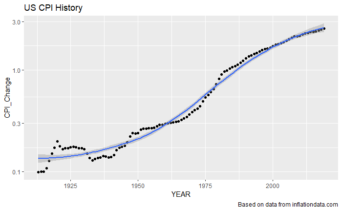

```r
ggplot(data=New_CPI,aes(x=YEAR,y=CPI_Change))+geom_point()+scale_y_log10() + geom_smooth() + labs(title = "US CPI History", caption = "Based on data from inflationdata.com")
```

Lets see if we can create a graphic that highlights the difference in CPI by year.

```r
AveVec <- Avg_CPI$AVE.
DifferenceInCPI <- diff(AveVec)
revDiff <- rev(DifferenceInCPI)
```

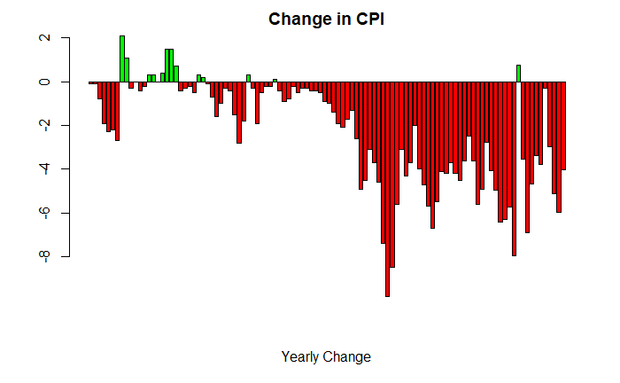

```r
barplot(revDiff, main = "Change in CPI", xlab ="Yearly Change", col = ifelse(revDiff<0, 'red', 'green'))
```

Note, there has only every been 13 years since the beginning of the 20th century in which your dollar from the year before could get you more than it could in your current year.

```r
head(WageGap)
```

```
  Year Lowest Second  Third  Fourth   Fifth
1 2018 35.864 63.023 96.340 150.117 279.240
2 2017 33.551 60.032 92.358 145.380 261.508
3 2016 32.400 57.944 89.769 139.568 251.183
4 2015 30.311 55.376 86.310 133.525 239.188
5 2014 29.100 52.697 82.032 129.006 230.030
6 2013 28.894 50.520 78.000 121.059 217.032
```

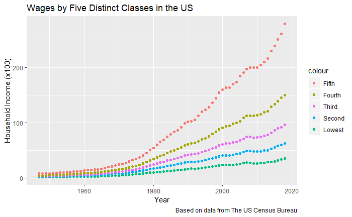

```r
#with and without education
g <- ggplot(data = WageGap) +
  geom_point(aes(x = Year, y = Lowest,colour = "Lowest")) +
  geom_point(aes(x = Year, y = Second, colour = "Second"))+
  geom_point(aes(x = Year, y = Third, colour = "Third")) +
  geom_point(aes(x = Year, y = Fourth, colour = "Fourth"))+
  geom_point(aes(x = Year, y = Fifth, colour = "Fifth"))
g + ylab("Household Income (x100)") + scale_shape_discrete() + labs(title = "Wages by Five Distinct Classes in the US", caption = "Based on data from The US Census Bureau")+ scale_color_discrete(breaks=c("Fifth", "Fourth", "Third", "Second", "Lowest"))
```

```r
Income_Per_Ed <- Income_Per_education %>% select(Quentile, Less.than.High.School, High.School, Some.College.or.Associates, Bachelor.s.Degree..)
head(Income_Per_Ed)
```

```
  Quentile Less.than.High.School High.School Some.College.or.Associates Bachelor.s.Degree..
1   Lowest                   367         422                        468                 658
2   Second                   476         548                        619                 919
3    Third                   606         749                        874                1383
4   Fourth                   783        1090                       1258                2064
5    Fifth                  1076        1535                       1764                2977
```

```r
ChangeInGap <- c(WageGap$Fifth - WageGap$Lowest)
```

```r
revChange <- rev(ChangeInGap)
```

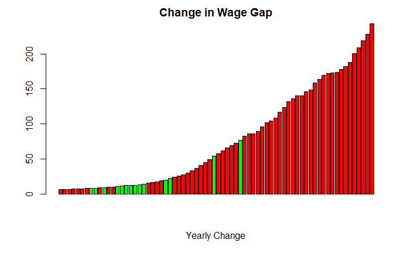

```r
barplot(revChange, main = "Change in Wage Gap", xlab ="Yearly Change", col = ifelse(revDiff<0, 'red', 'green'))
```

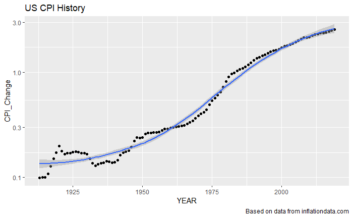

```r
ggplot(data=New_CPI,aes(x=YEAR,y=CPI_Change))+geom_point()+scale_y_log10() + geom_smooth() + labs(title = "US CPI History", caption = "Based on data from inflationdata.com")
```

For this next analysis I have broken groups by education and graphed their income accordingly. It is clear from this graph that a wage gap directly is impacted by those from the upper two classes. Their education creates even a second gap froom their peers in their respective financial classes.

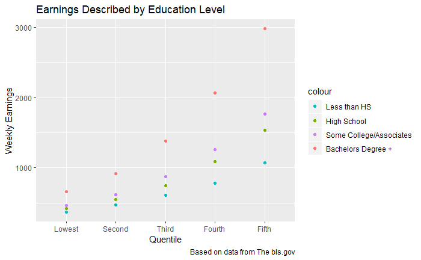

```r
Income_Per_Ed$Quentile <- factor(Income_Per_Ed$Quentile, levels=c("Lowest", "Second", "Third", "Fourth", "Fifth"))
g2 <- ggplot(data = Income_Per_Ed) +
  geom_point(aes(x = Quentile, y = Less.than.High.School,colour = "Less than HS")) +
  geom_point(aes(x = Quentile, y = High.School, colour = "High School"))+
  geom_point(aes(x = Quentile, y = Some.College.or.Associates, colour = "Some College/Associates")) +
  geom_point(aes(x = Quentile, y = Bachelor.s.Degree.., colour = "Bachelors Degree +"))
g2 + ylab("Weekly Earnings") + scale_shape_discrete() + labs(title = "Earnings Described by Education Level", caption = "Based on data from The bls.gov")+ scale_color_discrete(breaks=c("Less than HS", "High School", "Some College/Associates", "Bachelors Degree +"))
```

Clearly by this graphic, the cieling of earnings and number of jobs that allow people to climb to such wages are aided with further education.

What if we can use an Auto-Regressive Moving Average to predict the CPI of the future? That is, predicting how much your dollar will get you in the next few years.

```r
## First we implement a random walk ARIMA model
A_Data <- Avg_CPI$AVE.
B_Data <- Avg_CPI$YEAR
Future_CPI <- arima(A_Data, order = c(0,1,0))
m <- predict(Future_CPI, n.ahead = 10)
```

```r
m$se
```

```
Time Series:
Start = 108
End = 117
Frequency = 1
 [1]  3.378759  4.778287  5.852183  6.757519  7.555136  8.276237  8.939357  9.556575 10.136278 10.684575
```

This doesn’t look very good to me. It seems as though the model predicts very inconsistently and when we refer back to the data, we can see this is true.

```r
head(Avg_CPI)
```

```
  YEAR    AVE.
1 2019 255.151
2 2018 251.107
3 2017 245.120
4 2016 240.008
5 2015 237.017
6 2014 236.736
```

```r
## Now we implement a random walk ARIMA model with autocorrelation. Here we lag by 1 and autocorrect in order to create a more likely model.
A_Data <- Avg_CPI$AVE.
B_Data <- Avg_CPI$YEAR
Future_CPI <- arima(A_Data, order = c(1,1,0))
m2 <- predict(Future_CPI, n.ahead = 10)
```

```r
m2
```

```
$pred
Time Series:
Start = 108
End = 117
Frequency = 1
 [1] 9.811408 9.732923 9.663392 9.601793 9.547221 9.498875 9.456045 9.418101 9.384485 9.354704

$se
Time Series:
Start = 108
End = 117
Frequency = 1
 [1]  1.552834  3.314741  5.309169  7.450398  9.682151 11.965685 14.273452 16.585492 18.887208 21.167914
```

```r
### Keep in mind we are at a CPI of 255.15 today.
TodayCPI = 255.15
PredictedCPI =c(1.5528,3.3147,5.3092,7.4504,9.6822,11.9657,14.2735,16.5855,18.8872,21.1679)
 b = 2019
 PredVector <- rep("", times=length((PredictedCPI)))
 for(i in seq_along(PredictedCPI)){
   holder <- c(PredictedCPI[i]+TodayCPI)
   PredVector[i]<-holder
}
 PredVector
```

```
 [1] "256.7028" "258.4647" "260.4592" "262.6004" "264.8322" "267.1157" "269.4235" "271.7355" "274.0372" "276.3179"
```

```r
JoinedDF <- merge(Income_Per_Ed, WageGap)
```

```r
head(JoinedDF)
```

```
  Quentile Less.than.High.School High.School Some.College.or.Associates Bachelor.s.Degree.. Year Lowest Second  Third  Fourth   Fifth
1   Lowest                   367         422                        468                 658 2018 35.864 63.023 96.340 150.117 279.240
2   Second                   476         548                        619                 919 2018 35.864 63.023 96.340 150.117 279.240
3    Third                   606         749                        874                1383 2018 35.864 63.023 96.340 150.117 279.240
4   Fourth                   783        1090                       1258                2064 2018 35.864 63.023 96.340 150.117 279.240
5    Fifth                  1076        1535                       1764                2977 2018 35.864 63.023 96.340 150.117 279.240
6   Lowest                   367         422                        468                 658 2017 33.551 60.032 92.358 145.380 261.508
```

In conclusion, it looks as though earing a college degree, though it may not pay off initially, may create great opportunity for those as they progress in their career in the USA. With CPI continuing on an upward trend, it is still a good time to earn a degree regardless of the cost of it.